# Models

Mangaraj & Saha

## Decision Tree

We partition the data to training (80%) and test data (20%).

Creating the decision tree.  
Class models: display the classification rate at the node, expressed as the number of correct classifications and the number of observations in the node.

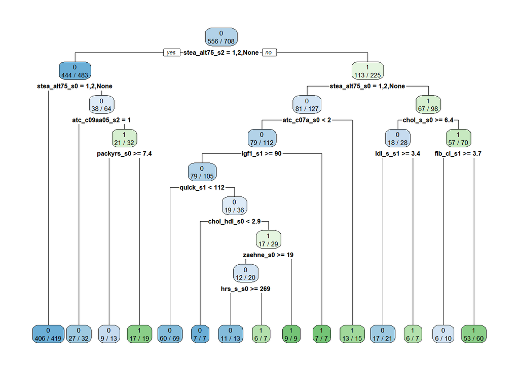

Class models: misclassification rate at the node, expressed as the number of incorrect classifications and the number of observations in the node.

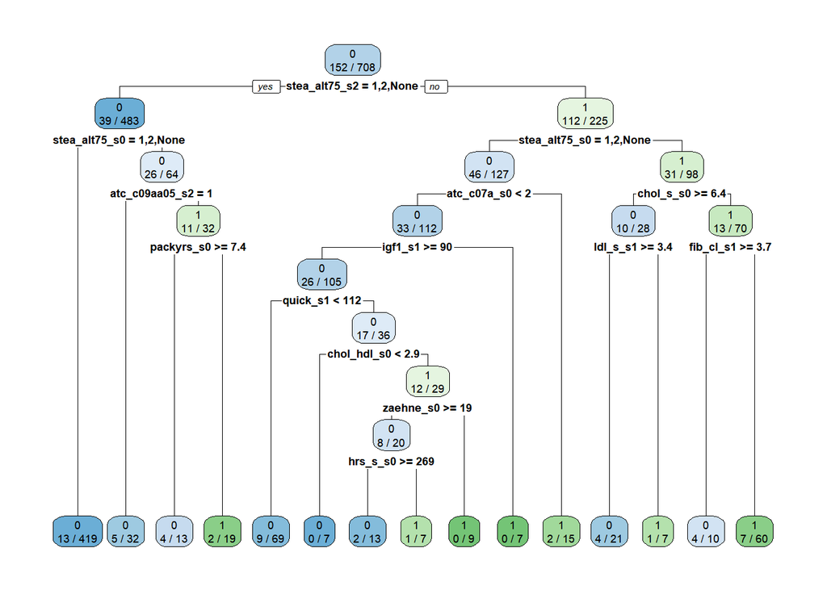

Class models: the probability of the fitted class.

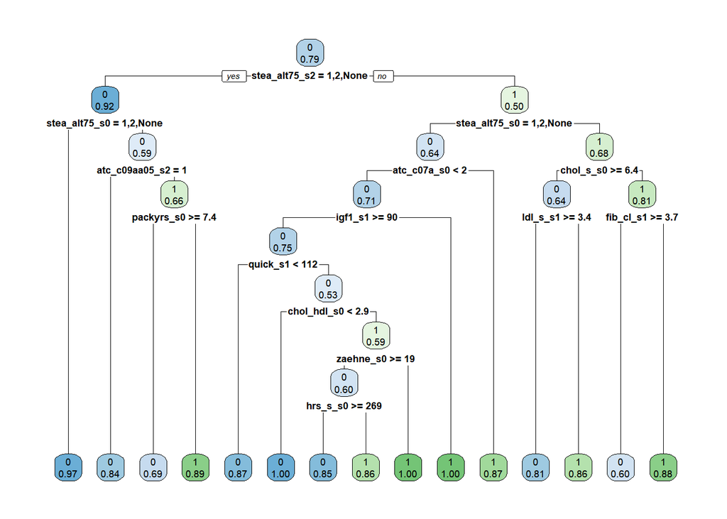

The summary gives the complete information about the tree,

- The number of nodes, information regarding each node,
- Information regarding each split and split conditions,
- Class counts over the data as well as the probabilities of classes at eah node.
- It also gives info about primary split and surrogate splits A primary splitting rule : is always calculated by default, and it provides for the assignment of observations when the predictor variable is missing, even when there are no missing values in the training data. This allows for the possibility of missing values when you are scoring new data A surrogate split : The purpose of a surrogate rule is to handle the assignment of observations by using an alternative variable that has similar predictive ability and has nonmissing values in observations where the primary predictor is missing.

```
## Call:
## rpart(formula = liver_fat ~ ., data = train_dt)
##   n= 708
##
##           CP nsplit rel error    xerror       xstd
## 1 0.11842105      0 1.0000000 1.0000000 0.07187849
## 2 0.07236842      2 0.7631579 0.8684211 0.06817702
## 3 0.05263158      3 0.6907895 0.8552632 0.06777591
## 4 0.04605263      4 0.6381579 0.8157895 0.06653606
## 5 0.03289474      5 0.5921053 0.8223684 0.06674659
## 6 0.01644737      9 0.4605263 0.7697368 0.06501693
## 7 0.01315789     13 0.3684211 0.7631579 0.06479323
## 8 0.01000000     14 0.3552632 0.7697368 0.06501693
##
## Variable importance
##      stea_alt75_s2      stea_alt75_s0        atc_c07a_s0
##                 16                 10                  3
##           hrs_s_s0          chol_s_s0            stea_s0
##                  2                  2                  2
##     atc_c09aa05_s2            igf1_s1       atc_c07ab_s0
##                  2                  2                  2
##         abstain_s2        diabetes_s2         physact_s2
##                  2                  2                  2
##          sleepp_s2         smoking_s2           ldl_s_s0
##                  2                  2                  2
##          alat_s_s0        chol_hdl_s0         som_bmi_s0
##                  2                  2                  2
##            tg_s_s0        som_tail_s0           quick_s1
##                  2                  2                  2
##         alkligt_s0         packyrs_s0            tg_s_s1
##                  2                  2                  2
##          asat_s_s0        som_tail_s1           ggt_s_s0
##                  2                  1                  1
##           ldl_s_s1           ncigd_s0          zaehne_s0
##                  1                  1                  1
##         som_bmi_s1          fib_cl_s1            apob_s0
##                  1                  1                  1
##        age_ship_s0         smoking_s0        age_ship_s1
##                  1                  1                  1
##       age_ship0_s0 mort_time_birth_s0         antihyp_s0
```

[output cut: 321 more lines]

```
##
## Node number 199: 9 observations
##   predicted class=1  expected loss=0  P(node) =0.01271186
##     class counts:     0     9
##    probabilities: 0.000 1.000
##
## Node number 396: 13 observations
##   predicted class=0  expected loss=0.1538462  P(node) =0.01836158
##     class counts:    11     2
##    probabilities: 0.846 0.154
##
## Node number 397: 7 observations
##   predicted class=1  expected loss=0.1428571  P(node) =0.009887006
##     class counts:     1     6
##    probabilities: 0.143 0.857
```

**Examining the complexity of the plot**  
This plots the various cp values.provides a graphical representation to the cross validated error summary. The cp values are plotted against the geometric mean to depict the deviation until the minimum value is reached.  
The value of cp should be least, so that the cross-validated error rate is minimum.

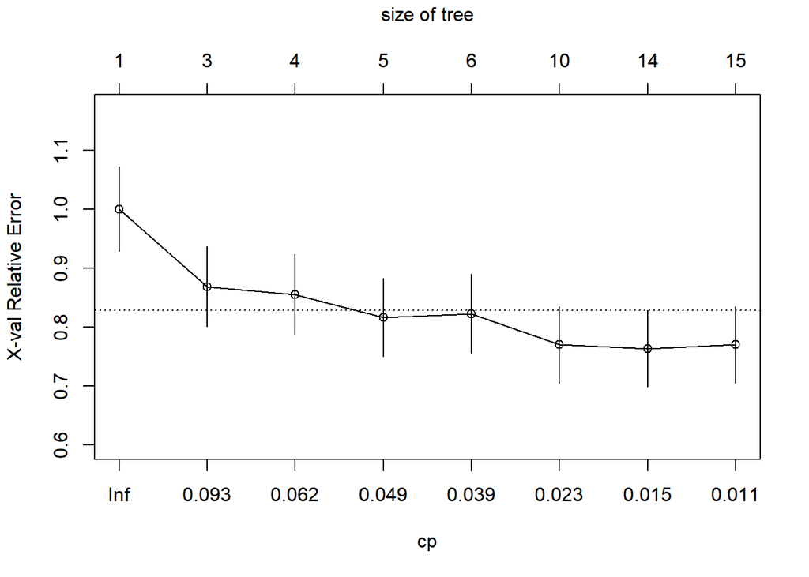

**Computing Accuracy of the rpart tree:**

```
## [1] 0.8202247
```

**Grow a tree with minsplit of 500 and max depth of 10**

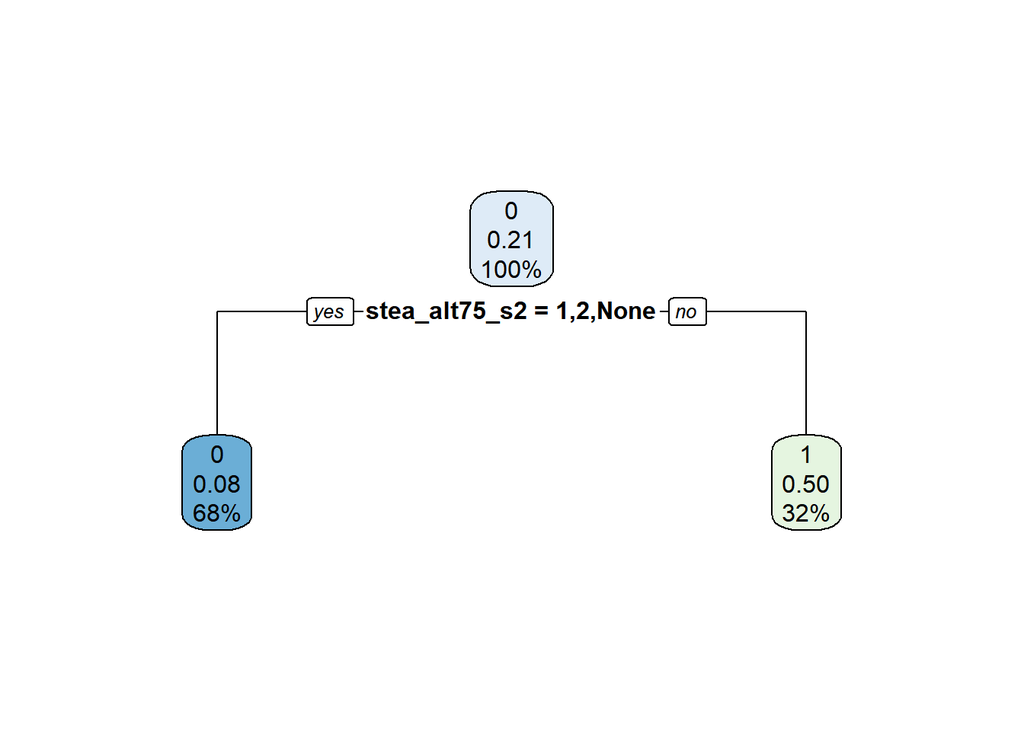

**Checking the accuracy of this approach:**

```
## [1] 0.8820225
```

**After Pruning:**

```
##   base_accuracy accuracy_preprun accuracy_postprun
## 1     0.8202247        0.8820225         0.8202247
```

**Decision Trees using selected features:**

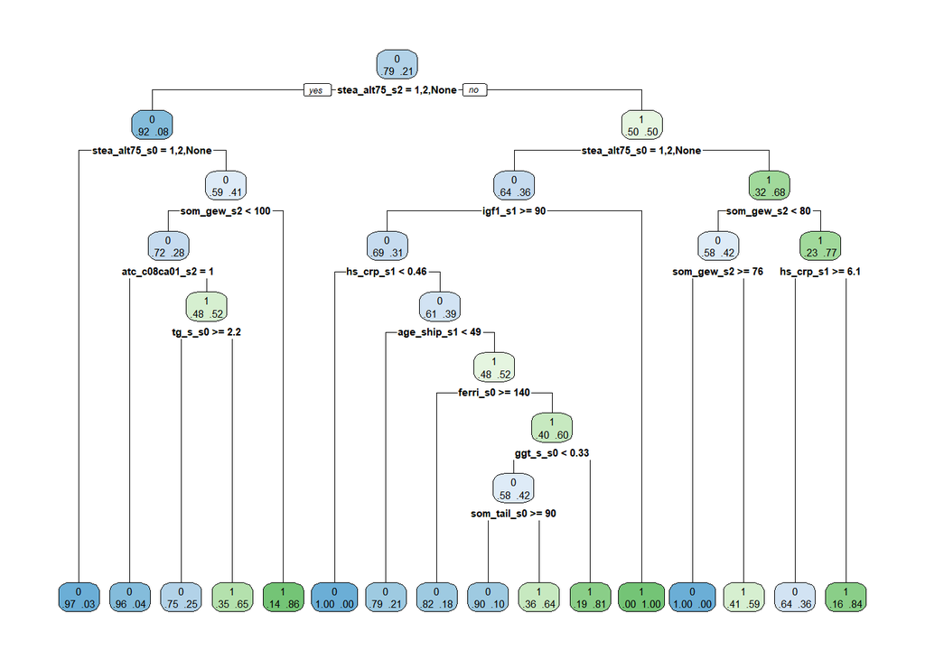

The summary gives the complete information about the tree, the number of nodes, information regarding each node, information regarding each split and split conditions, Class counts over the data as well as the probabilities of classes at eah node. It also gives info about primary split and surrogate splits. A primary split and surrogate split.

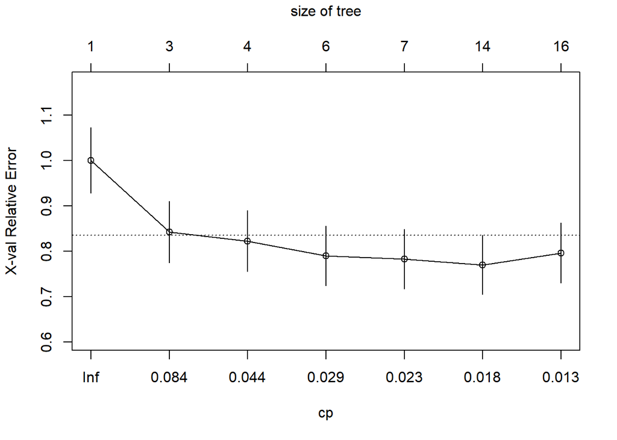

```
## [1] 0.8370787
```

```
## Call:
## rpart(formula = liver_fat ~ age_ship_s0 + som_bmi_s0 + som_tail_s0 +
##     som_huef_s0 + hrs_s_s0 + asat_s_s0 + alat_s_s0 + ggt_s_s0 +
##     tg_s_s0 + ferri_s0 + igf1_s0 + stea_alt75_s0 + stea_s0 +
##     age_ship_s1 + som_bmi_s1 + som_tail_s1 + som_huef_s1 + fib_cl_s1 +
##     hrs_s_s1 + tg_s_s1 + hdl_s_s1 + hs_crp_s1 + igf1_s1 + diabetes_s2 +
##     smoking_s2 + abstain_s2 + hyperlipid_s2 + earm_s2 + stea_alt75_s2 +
##     stea_s2 + atc_c07a_s2 + atc_c07ab_s2 + atc_c08_s2 + atc_c08ca01_s2 +
##     age_ship0_s0 + diabp_s0 + avs_s0 + mac_s0 + metsyn_s0 + waistc_s0 +
##     waiidf_s0 + whratc_s0 + antihyp_s0 + mort_time_birth_s0 +
##     som_gew_s2, data = train_dt)
##   n= 708
##
##           CP nsplit rel error    xerror       xstd
## 1 0.11842105      0 1.0000000 1.0000000 0.07187849
## 2 0.05921053      2 0.7631579 0.8421053 0.06736879
## 3 0.03289474      3 0.7039474 0.8223684 0.06674659
## 4 0.02631579      5 0.6381579 0.7894737 0.06567787
## 5 0.01973684      6 0.6118421 0.7828947 0.06545923
## 6 0.01644737     13 0.4605263 0.7697368 0.06501693
## 7 0.01000000     15 0.4276316 0.7960526 0.06589486
##
## Variable importance
##      stea_alt75_s2      stea_alt75_s0         som_gew_s2
##                 21                 13                  6
##        som_tail_s0          hs_crp_s1         som_bmi_s0
##                  5                  4                  4
##            igf1_s1           ggt_s_s0            stea_s0
##                  3                  3                  3
##        som_tail_s1            tg_s_s0          alat_s_s0
##                  3                  3                  3
##         som_bmi_s1           hrs_s_s0        som_huef_s0
##                  3                  3                  2
##     atc_c08ca01_s2         atc_c08_s2           ferri_s0
##                  2                  2                  2
##         abstain_s2        diabetes_s2         smoking_s2
##                  2                  2                  2
##        age_ship_s1        age_ship_s0 mort_time_birth_s0
##                  2                  1                  1
##       age_ship0_s0             avs_s0             mac_s0
```

[output cut: 337 more lines]

```
##
## Node number 207: 21 observations
##   predicted class=1  expected loss=0.1904762  P(node) =0.02966102
##     class counts:     4    17
##    probabilities: 0.190 0.810
##
## Node number 412: 10 observations
##   predicted class=0  expected loss=0.1  P(node) =0.01412429
##     class counts:     9     1
##    probabilities: 0.900 0.100
##
## Node number 413: 14 observations
##   predicted class=1  expected loss=0.3571429  P(node) =0.01977401
##     class counts:     5     9
##    probabilities: 0.357 0.643
```

**Cross validated error summary:**

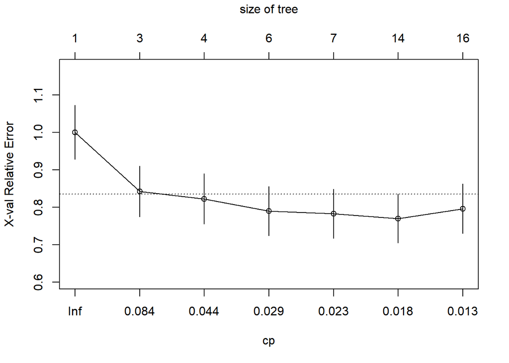

**Accuracy:**

```
## [1] 0.8370787
```

**Growing a tree with minSplit 200 and MaxDepth 10:**

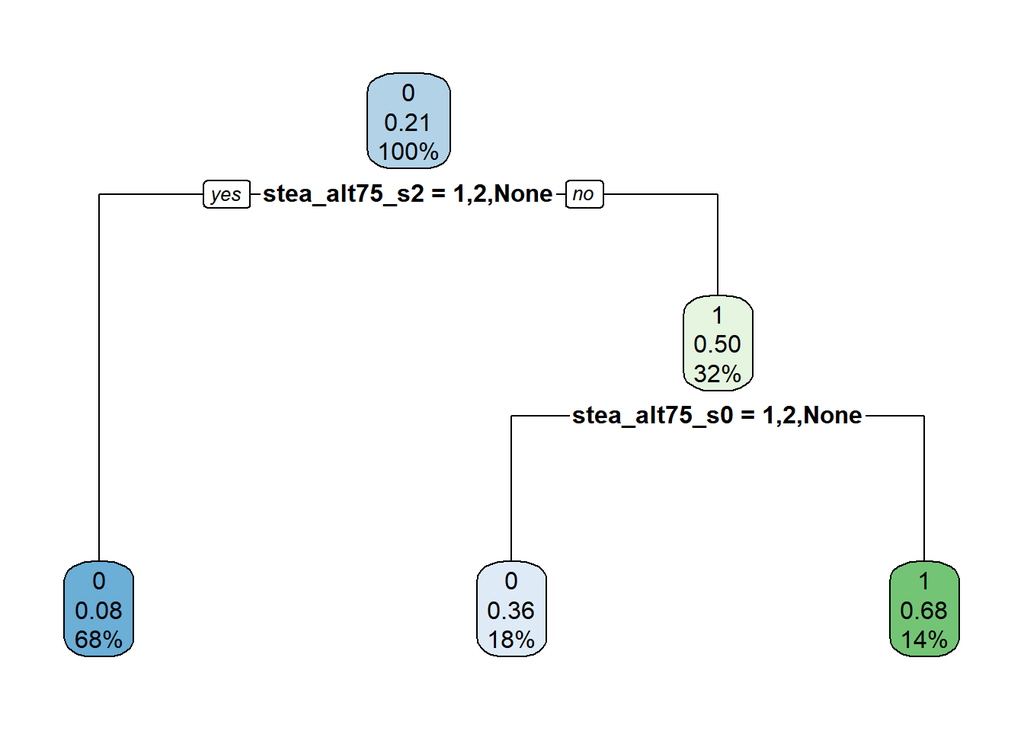

**Accuracy:**

```
## [1] 0.8595506
```

**Growing a tree with minSplit 100 and MaxDepth 10:**

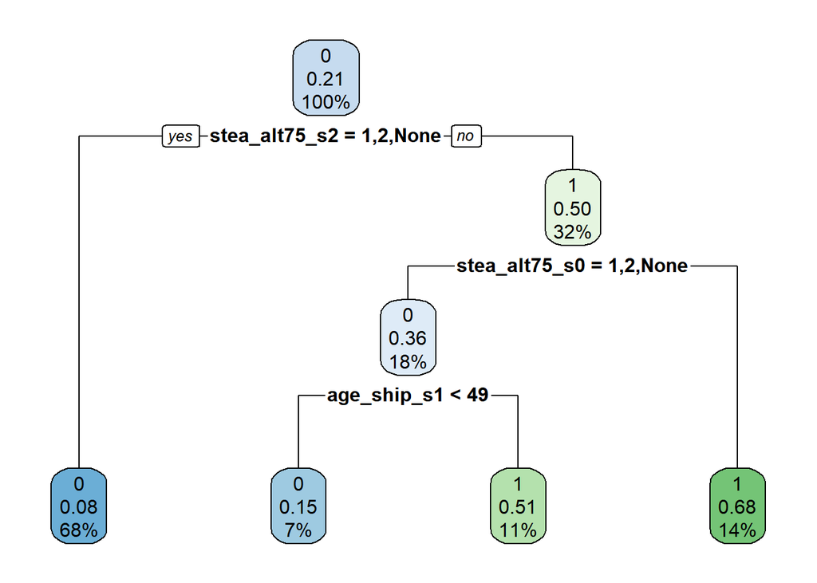

**Accuracy:**

```
## [1] 0.8876404
```

```
##   base_accuracy2 accuracy2 accuracy3
## 1      0.8370787 0.8595506 0.8876404
```

```
## [1] 0.8876404
```

**DT with rpart package with Important Features from Random Forest:**

```
## [1] "print hocche."
```

```
##
## Classification tree:
## rpart(formula = liver_fat ~ ., data = train_dt[w_rf1])
##
## Variables actually used in tree construction:
## [1] age_ship0_s0  chol_hdl_s0   som_bmi_s1    som_gew_s2    som_tail_s0
## [6] stea_alt75_s2 stea_s0       tg_s_s1
##
## Root node error: 152/708 = 0.21469
##
## n= 708
##
##         CP nsplit rel error  xerror     xstd
## 1 0.118421      0   1.00000 1.00000 0.071878
## 2 0.042763      2   0.76316 0.79605 0.065895
## 3 0.036184      4   0.67763 0.83553 0.067163
## 4 0.032895      6   0.60526 0.83553 0.067163
## 5 0.026316      8   0.53947 0.85526 0.067776
## 6 0.019737      9   0.51316 0.77632 0.065239
## 7 0.013158     10   0.49342 0.76316 0.064793
## 8 0.010000     13   0.45395 0.77632 0.065239
```

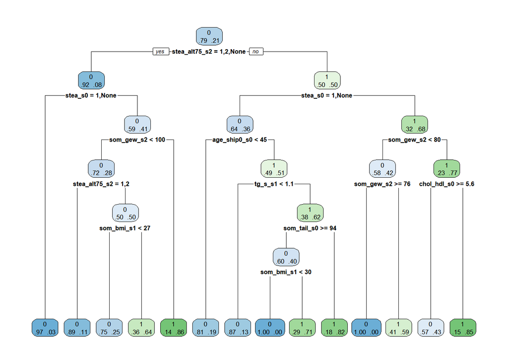

**Examining Complexity:**

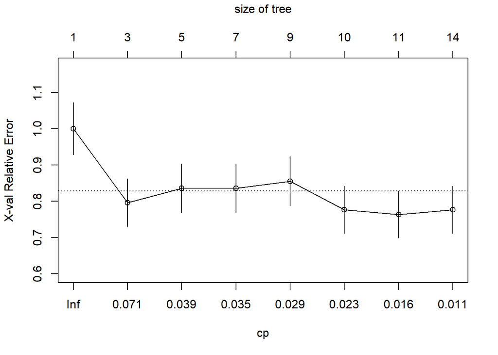

**Accuracy:**

```
## [1] 0.8202247
```

**Grow a tree with minsplit of 200 and max depth of 10**

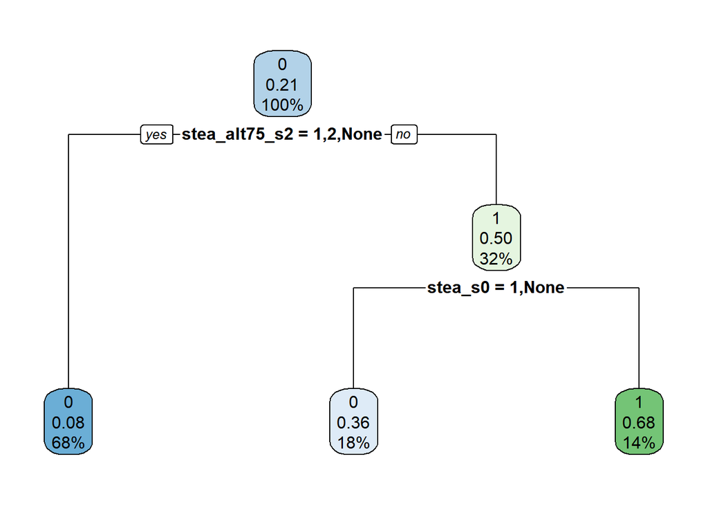

**Accuracy:**

```
## [1] 0.8707865
```

**Grow a tree with minsplit of 100 and max depth of 10**

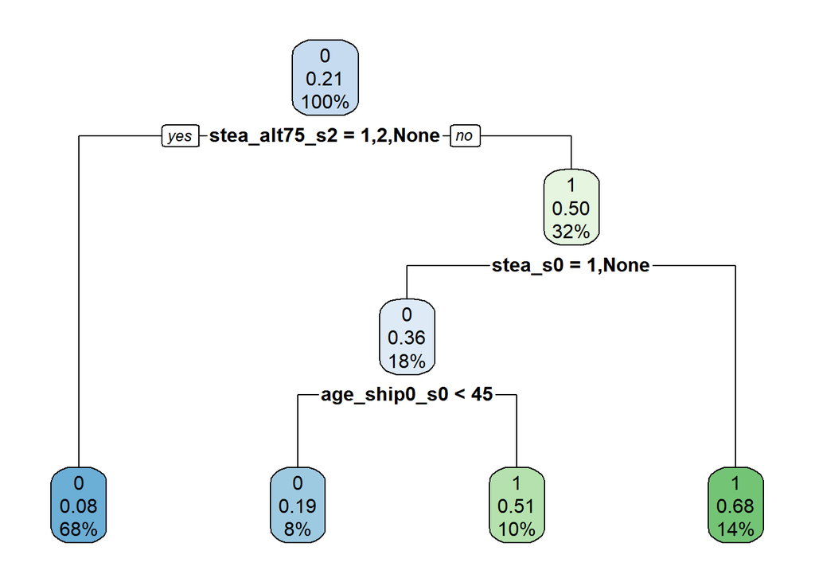

**Accuracy:**

```
## [1] 0.8820225
```

**After Pruning:**

```
##   base_accuracy3 accuracy_pre3 accuracy_post3
## 1      0.8202247     0.8707865      0.8820225
```

**Tabulation of work so far:**

```
##      Model_Name  Base_Acc Pre_Prune_Acc Post_Prune_Acc
## 1        Model1 0.8202247     0.8820225      0.8202247
## 2 Model1_Boruta 0.8370787     0.8595506      0.8876404
## 3 Model1_RanFor 0.8202247     0.8707865      0.8820225
```

### Evaluation

The decision tree with selected features using Boruta method has given better results.

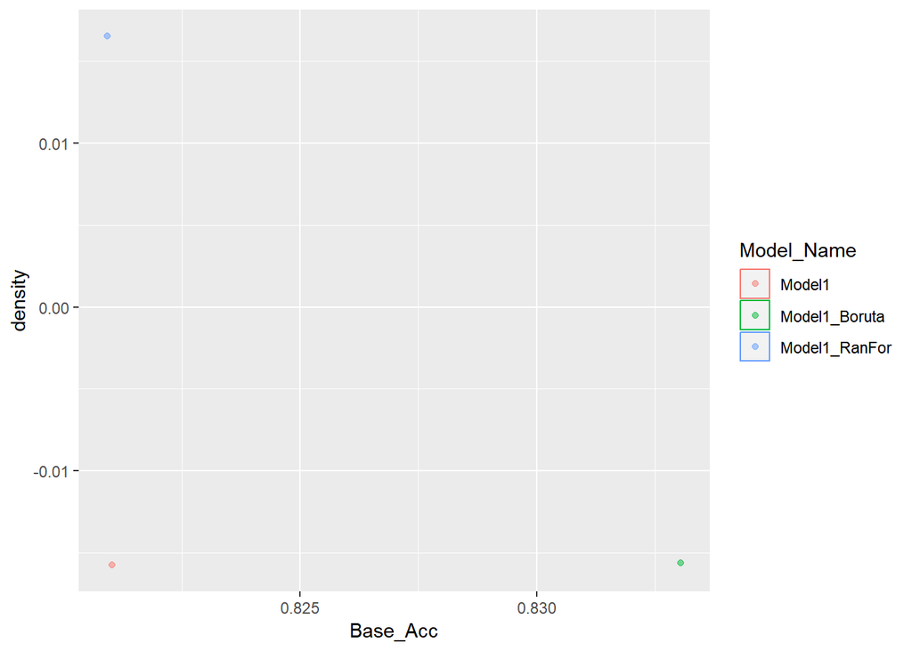

[figure not shown]

## Random Forest

We are dividing the dataset into two parts:

- Training Data (80%)
- Test Data (20%)

We will implement Random Forest Model in 4 ways:

- Default values of MTry and NTree
- Run 10 times, for different values of NTrees and analyse the Out of Bag (OOB) errors.
- Run 10 times, for different values of MTry and analyse the OOB errors.
- Run for optimum number of MTry and NTrees where error is minimised and stabilises.

### Approach 1: Default values of MTry and NTree

```
## running: classification cross-validation with 10 iterations
```

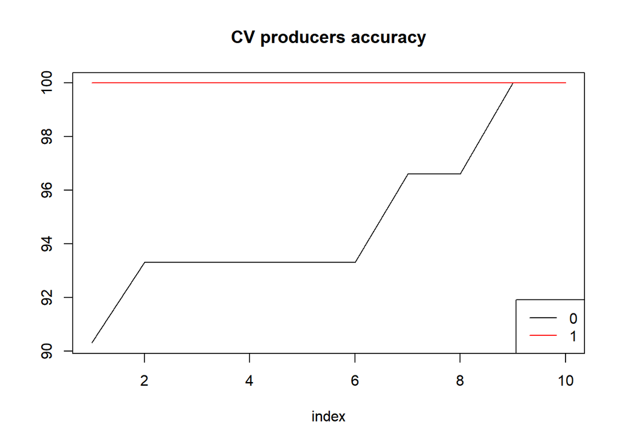

**Fig: Cross Validation Producers Accuracy.**

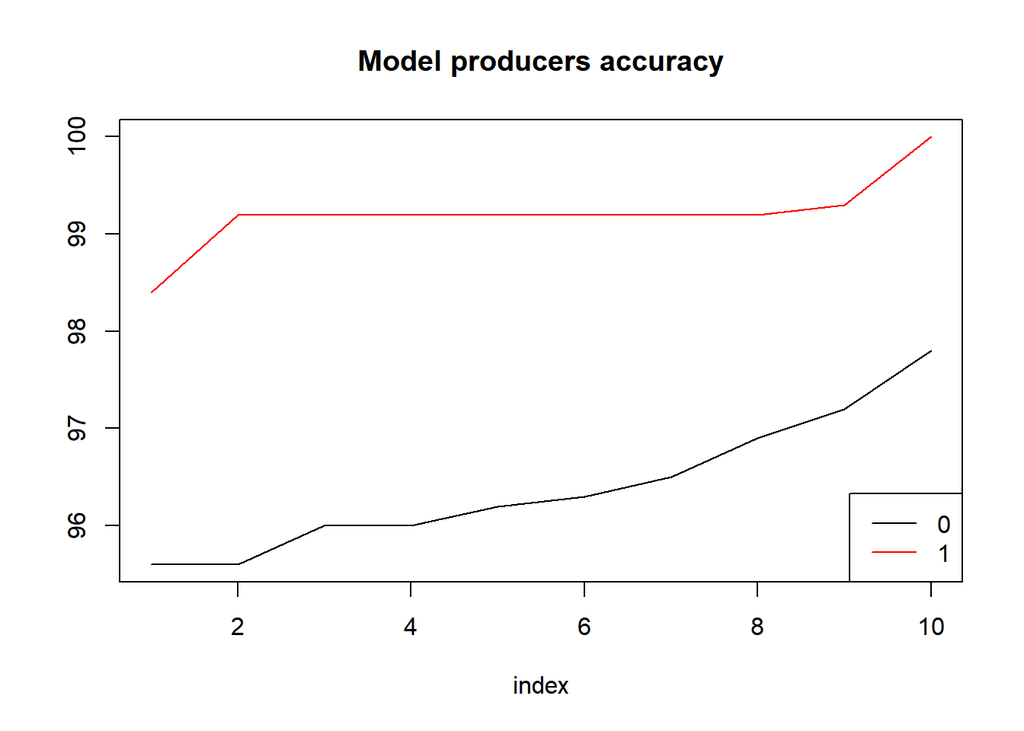

**Fig: Model Producers Accuracy.**

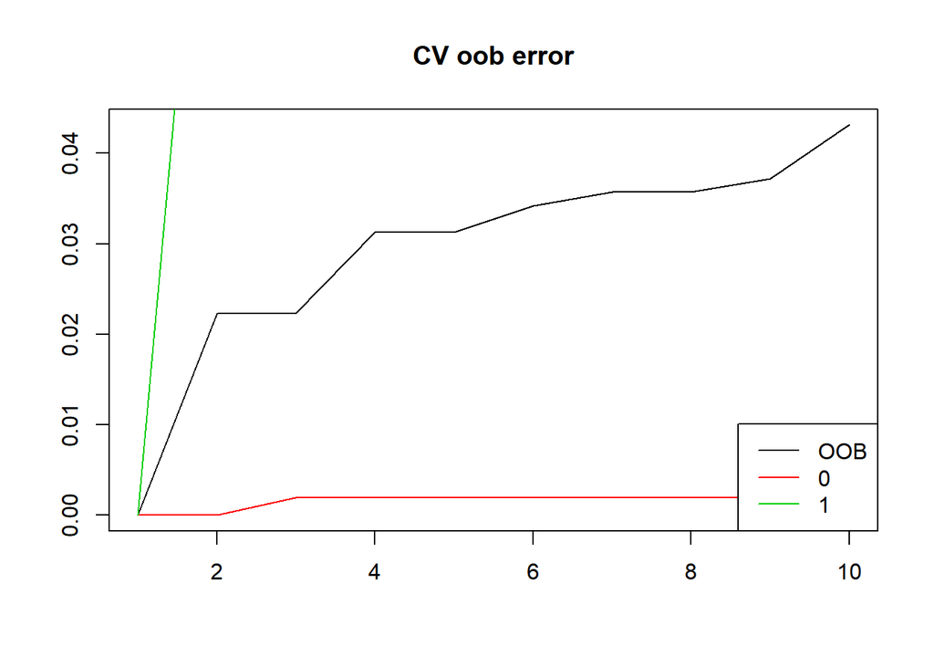

**Fig: Cross Validation vs Model OOB.**

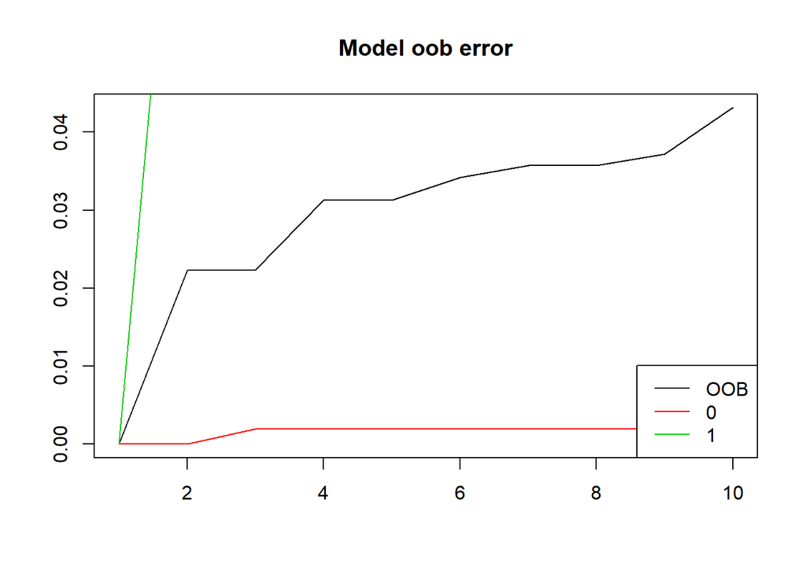

**Fig: Model OOB Error.**

```
## Confusion Matrix and Statistics
##
##           Reference
## Prediction   0   1
##          0 555   0
##          1   0 153
##
##                Accuracy : 1
##                  95% CI : (0.9948, 1)
##     No Information Rate : 0.7839
##     P-Value [Acc > NIR] : < 2.2e-16
##
##                   Kappa : 1
##  Mcnemar's Test P-Value : NA
##
##             Sensitivity : 1.0000
##             Specificity : 1.0000
##          Pos Pred Value : 1.0000
##          Neg Pred Value : 1.0000
##              Prevalence : 0.7839
##          Detection Rate : 0.7839
##    Detection Prevalence : 0.7839
##       Balanced Accuracy : 1.0000
##
##        'Positive' Class : 0
##
```

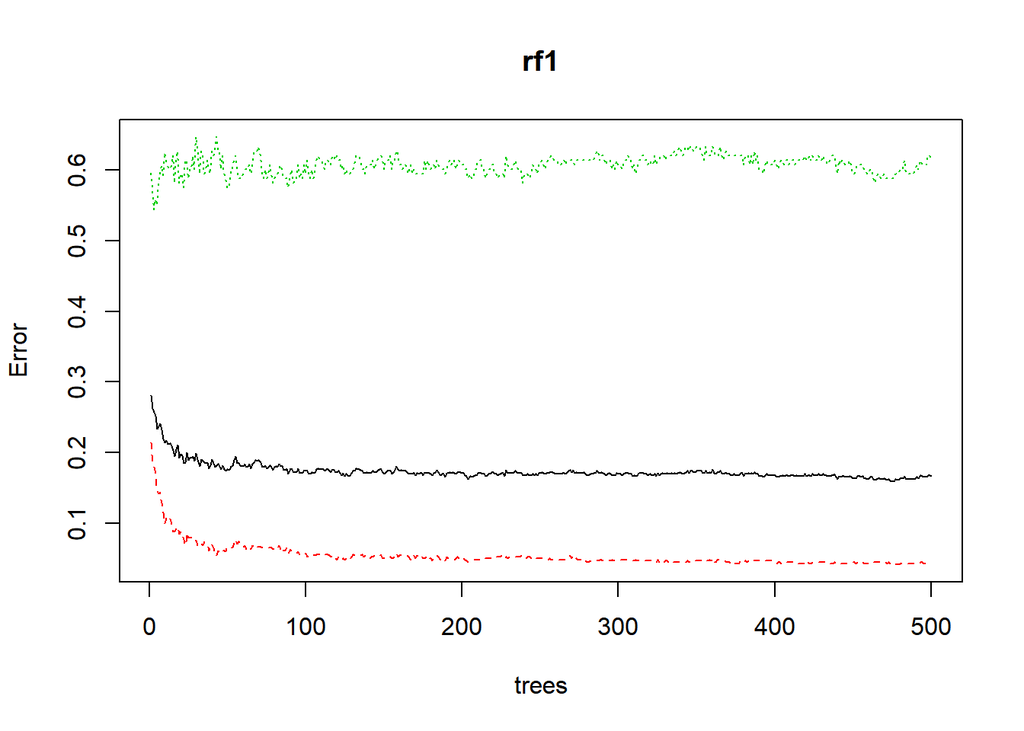

**Fig: Error Rate for Random Forest Model approach 1.**

### Approach 2: Optimising MTry.

The number of variables available for splitting at each tree node, in the random forests literature, is referred to as the mtry parameter. **How does optimising MTrys affect?**

While trying to optimise MTrys, we found out the following:

```
## mtry = 18  OOB error = 16.67%
## Searching left ...
## mtry = 12    OOB error = 17.37%
## -0.04237288 0.01
## Searching right ...
## mtry = 27    OOB error = 15.25%
## 0.08474576 0.01
## mtry = 40    OOB error = 15.11%
## 0.009259259 0.01
```

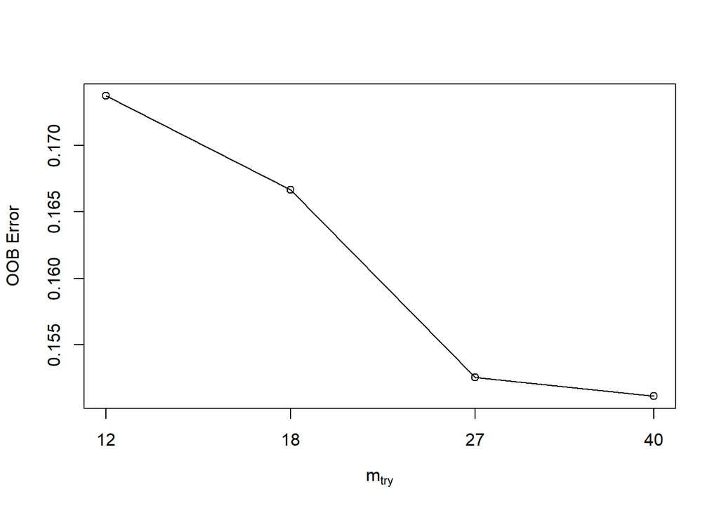

```
## running: classification cross-validation with 10 iterations
```

```
##        mtry  OOBError
## 12.OOB   12 0.1737288
## 18.OOB   18 0.1666667
## 27.OOB   27 0.1525424
## 40.OOB   40 0.1511299
```

The best MTry which has minimum OOB Error is -

```
## [1] 40
```

#### Test Results.

When tested with the testing data:

```
##   2   3   9  11  15  23  25  29  30  42  44  63  71  75  77  78  84  86
##   0   0   0   0   0   0   0   0   0   0   0   0   1   0   0   0   0   0
##  92 120 122 126 128 135 138 139 143 144 145 154 155 160 161 165 166 167
##   0   0   0   0   0   1   0   0   0   0   0   0   0   0   0   1   0   0
## 173 194 198 207 208 231 232 237 242 243 244 251 253 266 283 284 291 293
##   0   1   1   0   0   0   0   1   0   0   0   1   0   0   0   0   0   1
## 298 301 302 309 328 333 334 337 339 348 356 357 364 371 372 382 393 399
##   1   0   1   0   0   0   0   0   0   0   0   1   0   1   0   0   0   1
## 400 402 404 405 411 414 420 422 424 427 432 436 437 438 443 448 449 453
##   1   0   0   0   0   0   0   0   0   0   0   0   0   0   0   0   0   0
## 466 473 474 478 488 491 498 503 516 522 526 529 531 541 546 548 558 562
##   0   0   0   0   0   0   0   0   0   0   0   0   0   0   1   0   0   0
## 563 564 568 569 572 575 576 578 581 582 583 595 597 598 601 604 610 612
##   0   0   0   0   0   0   0   0   0   0   0   0   0   0   0   0   0   0
## 615 627 630 636 639 643 647 651 656 659 663 673 678 681 683 693 702 704
##   0   0   0   0   0   1   0   0   0   0   0   0   0   0   0   0   0   0
## 713 715 728 732 739 741 746 753 758 761 762 770 776 778 782 783 790 791
##   0   0   0   0   0   0   0   0   0   1   0   0   0   0   1   0   1   1
## 792 793 800 810 812 817 824 827 838 846 849 858 860 866 869 876
##   0   0   0   1   1   0   0   1   1   0   0   1   1   0   0   0
## Levels: 0 1
```

### Approach 3: Optimisng NTrees.

N Trees refer to the number of decision trees we are building. Larger number of trees produce more stable models and covariate importance estimates, but require more memory and a longer run time. When we try to find out the optimum number of N Trees, we got this:

```
##     0  1 class.error
## 0 533 22  0.03963964
## 1  94 59  0.61437908
```

```
## running: classification cross-validation with 10 iterations
```

```
##
## Call:
## summary.resamples(object = results)
##
## Models: 700, 1000, 1500
## Number of resamples: 30
##
## Accuracy
##           Min.   1st Qu.    Median      Mean   3rd Qu.      Max. NA's
## 700  0.7746479 0.8056841 0.8240079 0.8215948 0.8309859 0.8732394    0
## 1000 0.7746479 0.8056841 0.8285714 0.8225207 0.8309859 0.8714286    0
## 1500 0.7746479 0.8077381 0.8240079 0.8215420 0.8333333 0.8591549    0
##
## Kappa
##           Min.   1st Qu.    Median      Mean   3rd Qu.      Max. NA's
## 700  0.1009174 0.2634062 0.3357664 0.3067246 0.3947812 0.5412778    0
## 1000 0.1009174 0.2349711 0.3324501 0.3103557 0.3769384 0.5116279    0
## 1500 0.1009174 0.2371660 0.3324501 0.3061302 0.3971532 0.4748521    0
```

#### Test Results.

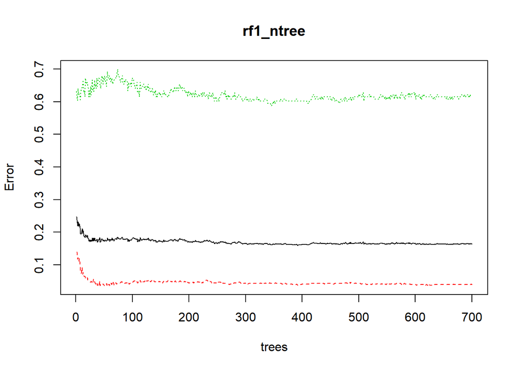

### Approach 4: Optimisnig NTrees and MTrys to minimise error.

In this approach, we take the optimised MTrys and NTrees to find the best model.

```
##     0  1 class.error
## 0 528 27  0.04864865
## 1  78 75  0.50980392
```

```
## running: classification cross-validation with 10 iterations
```

```
##     0  1 class.error
## 0 528 27  0.04864865
## 1  78 75  0.50980392
```

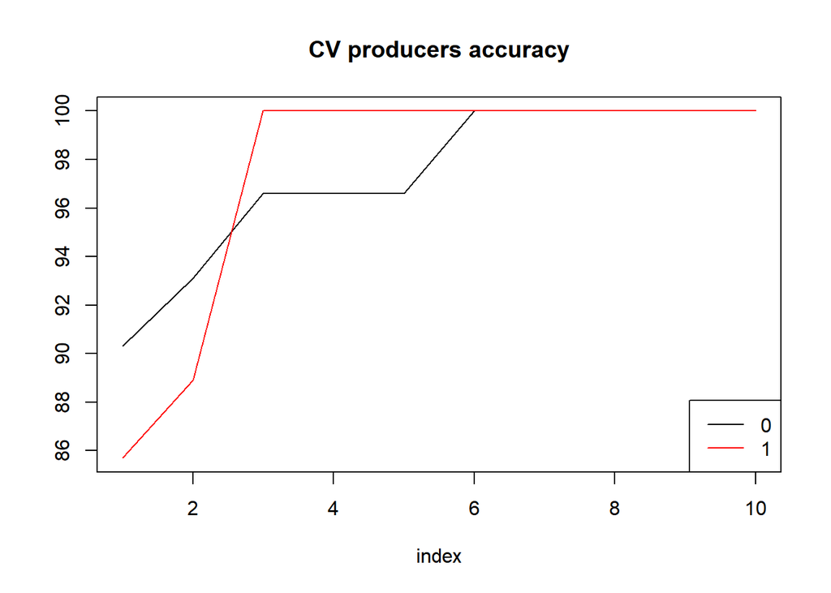

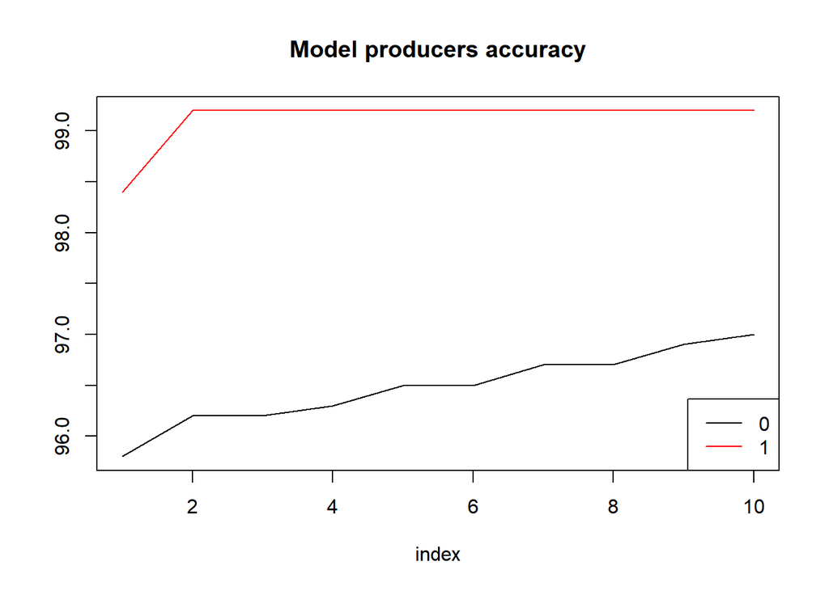

#### Test Results.

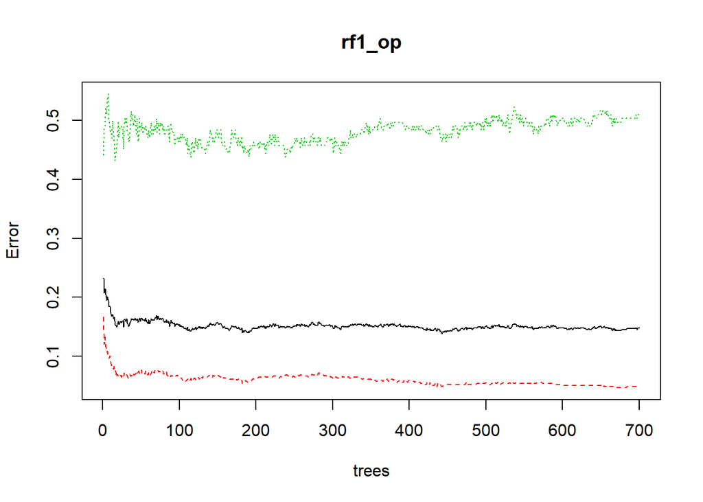

## Linear Regression

Now we try and implement the Linear Regression model on the data.  
We load the dataset, choose the features selected by the Boruta Method and the random forest method.  
We further divide the dataset to train and test data.

```
##   0   1
## 694 192
```

Here we plot a density curve to see the distribution od data of target variable (Liver_fat)  
Inference: Maximum people have a liver fat value les than 10 which is the threshhold limit.  
Any one having liver fat value more than 10 is considered to have fatty liver. This curve helps to see the data districution.

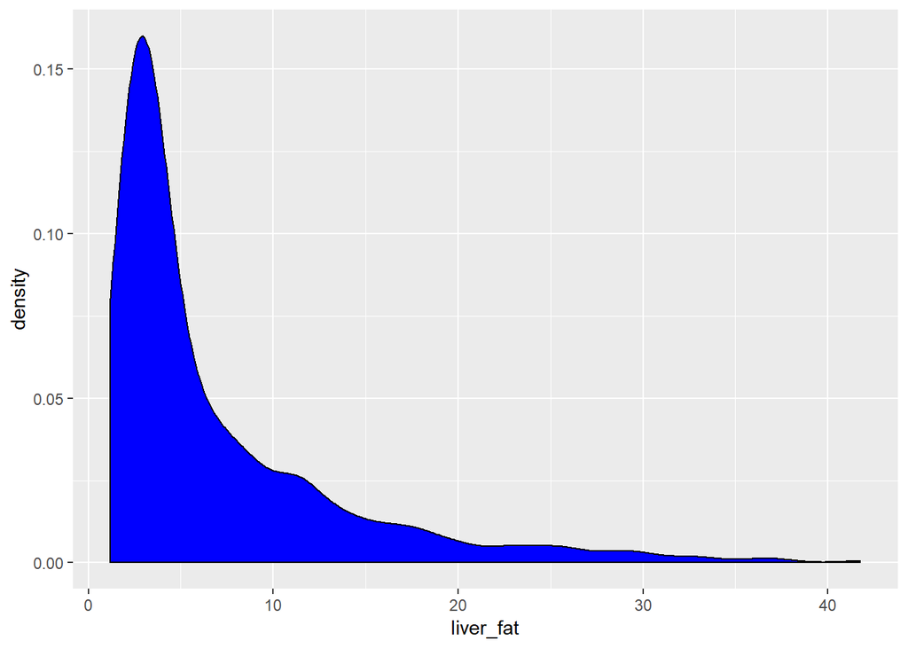

Density Graph: To check how much is the response variable close to normality For som_bmi_s0, the graph is right skewed (positive skew)

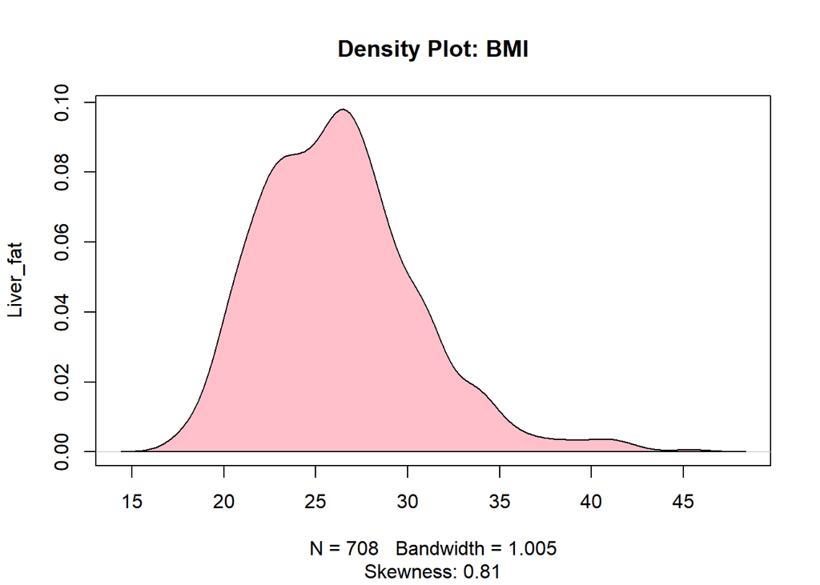

For ferri_s0 the graph is right skewed(positive skew)

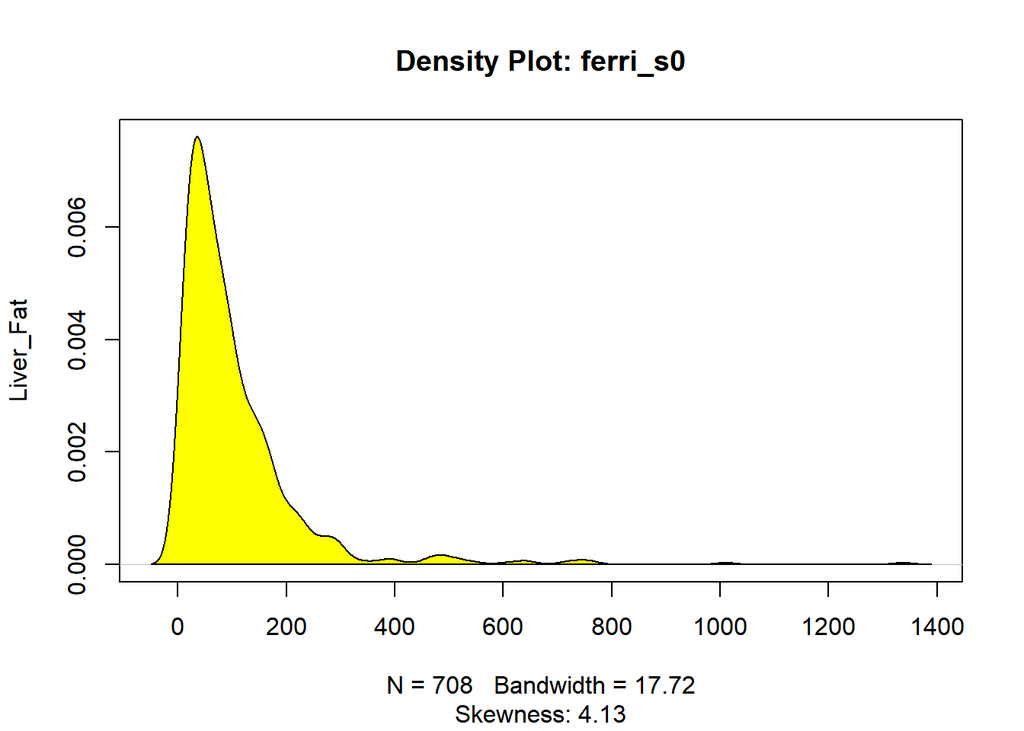

```
##   Model_Name p_Value      AIC      BIC   RSq     RMSE
## 1     Model1     2.2 4169.958 6159.183 85.96 7.618716
```